# Markdown Tradestats

Kirill Makarov & Jenna Prades

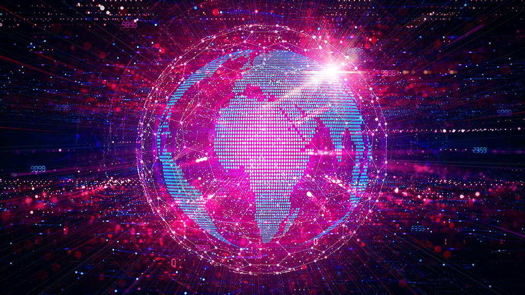

# Tradestats

## Présentation du jeu de données

Le jeu de données provient lui même de la blockchain et a été extrait de la bourse afin que les données soient le plus fiables et proches de la réalité possibles.

### Le MCD

| Symbols |
| --- |
| symbol |
| *token_address* |
| decimals |

| Prices |
| --- |
| price_usd |
| *token_id_* |
| decimals |
| day |

| Token |
| --- |
| *token_id* |
| symbol |

| Transactions |
| --- |
| *receipt_id* |
| token_in_address |
| amount_in |
| day |
| token_out_address |
| transaction_signer |

Pour réaliser l’analyse et répondre à la problématique posée, nous disposons des 4 fichiers précédents dans lesquels nous avons réalisé des jointures.

```r
data <- read.csv("C:/Users/6prad/Desktop/projet/shiny_analysis/data/final/swap_operations.csv")
```

### Le nom des colonnes

```r
colnames(data)
```

```
##  [1] "X"                  "token_in_id"        "day"
##  [4] "token_in_symbol"    "token_out_address"  "token_in_address"
##  [7] "receipt_id"         "amount_in"          "transaction_signer"
## [10] "decimals_token_in"  "token_out_symbol"   "price_usd"
## [13] "token_address"      "decimals"           "volume"
```

### Voici le résumé des données :

```r
summary(data)
```

```
##        X         token_in_id            day            token_in_symbol
##  Min.   :   61   Length:19973       Length:19973       Length:19973
##  1st Qu.:10652   Class :character   Class :character   Class :character
##  Median :26166   Mode  :character   Mode  :character   Mode  :character
##  Mean   :21448
##  3rd Qu.:31159
##  Max.   :36202
##  token_out_address  token_in_address    receipt_id          amount_in
##  Length:19973       Length:19973       Length:19973       Min.   :2.330e+02
##  Class :character   Class :character   Class :character   1st Qu.:2.593e+17
##  Mode  :character   Mode  :character   Mode  :character   Median :3.326e+21
##                                                           Mean   :5.277e+25
##                                                           3rd Qu.:1.997e+25
##                                                           Max.   :2.743e+28
##  transaction_signer decimals_token_in token_out_symbol     price_usd
##  Length:19973       Min.   : 4.00     Length:19973       Min.   :    0.000
##  Class :character   1st Qu.:18.00     Class :character   1st Qu.:    0.998
##  Mode  :character   Median :18.00     Mode  :character   Median :    3.774
##                     Mean   :18.25                        Mean   :  961.407
##                     3rd Qu.:24.00                        3rd Qu.:    4.274
##                     Max.   :24.00                        Max.   :21614.789
##  token_address         decimals         volume
##  Length:19973       Min.   : 4.00   Min.   :     0.00
##  Class :character   1st Qu.:18.00   1st Qu.:    21.37
##  Mode  :character   Median :18.00   Median :    89.96
##                     Mean   :18.25   Mean   :   487.87
##                     3rd Qu.:24.00   3rd Qu.:   471.80
##                     Max.   :24.00   Max.   :234769.66
```

## Le projet

Le projet Tradestats consiste en la realisation d’une application R Shiny qui sera par la suite publiee et donc accessible sur internet via Shinyapps.io.  
Nous avons réalisé plusieurs documents pour répondre au sujet, nous pouvons trouver sur GitHub (espace de partage de documents) un document qui explique comment a été réalisé le projet, avec les spécifications techniques, le fichier brut contenant le code créant l’application Shiny, un Document R.Markdown retracant la source de données, les informations présentes dans le jeu de données, quelques indicateurs statistiques et plusieurs graphiques présents dans l’application. Tout ceci dans l’objectif de répondre a la problématique posée.

### La problematique

Nous avons decide de centrer notre projet sur l’etude de la blockchain, les transactions associees a ces echanges et les traders concernes.  
C’est pourquoi nous avons decide de poser la problematique suivante  
Quelles sont les habitudes des traders sur la blockchain ?  
Pour mieux comprendre le comportement des personnes sur la bourse et voir s’il y a un modele particulier utilise par les traders ou des transactions phares.  
Pour repondre a cette question, nous avons developpe une application R Shiny basee sur des donnees extraites elles-memes de la blockchain.

### Qu’est ce que la blockchain

La blockchain permet de stocker et d’échanger de la valeur, comme des cryptomonnaies, sur internet sans intermédiaire centralisé. Une blockchain constitue une base de données qui contient l’historique de tous les échanges effectués entre ses utilisateurs depuis sa création de manière sécurisée, indestructible, impossible à effacer.

## Exploration des données

### Analyse du volume

```r
summary(data$volume)
```

```
##      Min.   1st Qu.    Median      Mean   3rd Qu.      Max.
##      0.00     21.37     89.96    487.87    471.80 234769.66
```

```r
sd(data$volume)
```

```
## [1] 2676.983
```

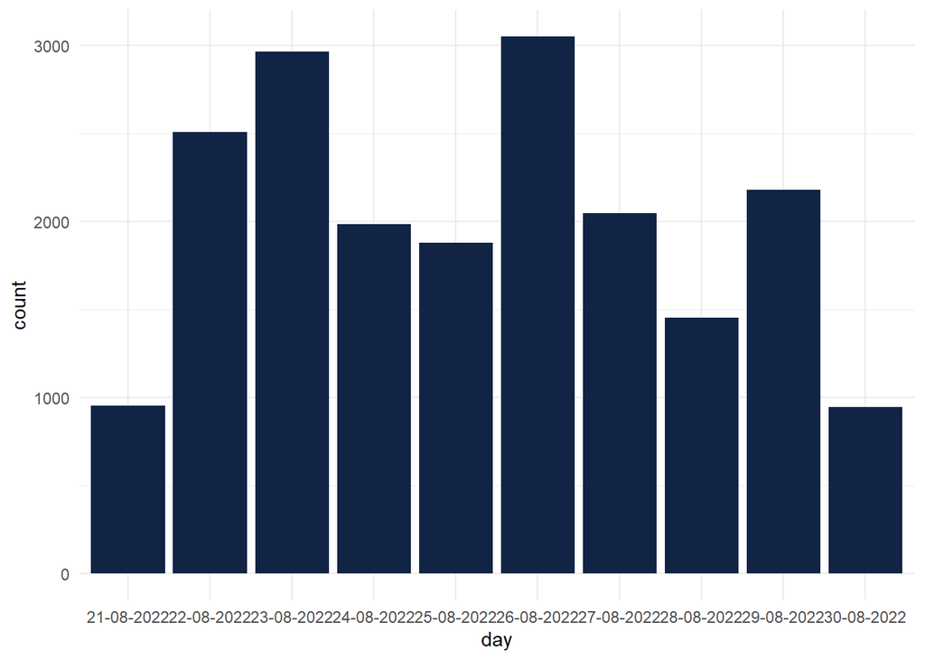

```r
library(ggplot2)
ggplot(data) +
 aes(x = day) +
 geom_bar(fill = "#112446") +
 theme_minimal()
```

Nous voyons que le 23 et le 26 admettent bien plus de transactions que pour les autres jours étudiés. Cela peut concevoir une certaine recurrence sur les échanges.

Nous allons comparer le nombre de transaction faites par jour avec le volume échangé pour voir si le jour influe sur le volume.

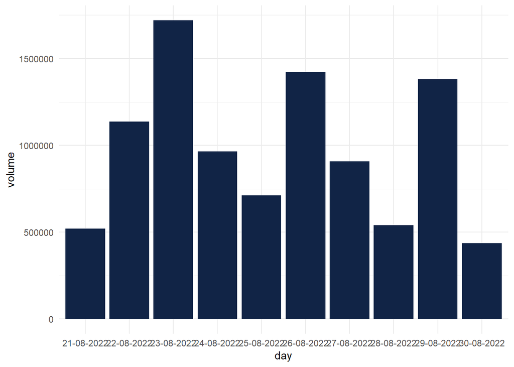

| Jour | Nb transaction | Volume | volume moyen/transaction |
| --- | --- | --- | --- |
| 21-08-2022 | 954 | 520655.2265 | 545.76 |
| 22-08-2022 | 2508 | 1137033.851 | 453.36 |
| 23-08-2022 | 2963 | 1719790.877 | 580.42 |
| 24-08-2022 | 1986 | 964743.6164 | 485.77 |
| 25-08-2022 | 1879 | 712603.0258 | 379.25 |
| 26-08-2022 | 3050 | 1422342.949 | 466.34 |
| 27-08-2022 | 2049 | 907148.4622 | 442.73 |
| 28-08-2022 | 1455 | 541152.9405 | 371.93 |
| 29-08-2022 | 2181 | 1381254.213 | 633.31 |
| 30-08-2022 | 948 | 437423.6403 | 461.42 |

```r
library(ggplot2)
ggplot(data) +
  aes(x = day, y = volume) +
  geom_col(fill = "#112446") +
  theme_minimal()
```

Nous pouvons voir du tableau précedent que le volume transité diffère en fonction du jour des transactions. Ainsi, le 29-08-2022 le volume moyen d’une transaction était supérieur aux autres jours étudiés, contre 371.93 le 28 soit la veille. C’est une autre remarque que l’on peut se faire pour répondre à la problématique.

### Analyse des prix

```r
summary(data$price_usd)
```

```
##      Min.   1st Qu.    Median      Mean   3rd Qu.      Max.
##     0.000     0.998     3.774   961.407     4.274 21614.789
```

```r
sd(data$price_usd)
```

```
## [1] 4240.713
```

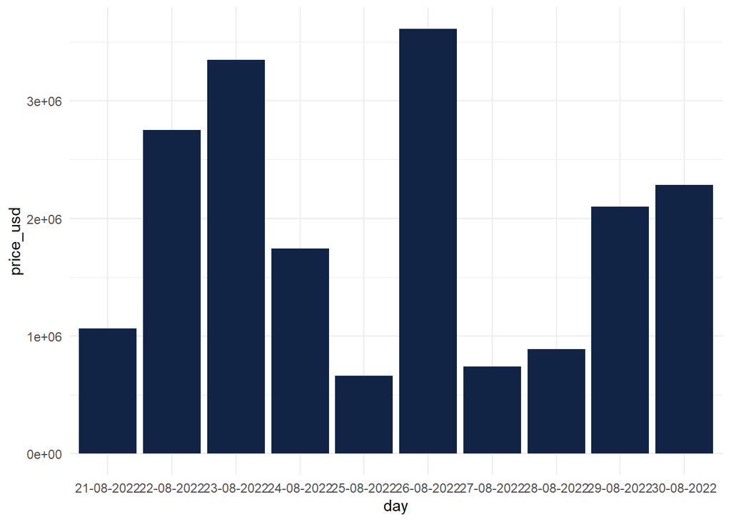

| Jour | Nb transaction | Prix | Prix moyen/transaction |
| --- | --- | --- | --- |
| 21-08-2022 | 954 | 1063987.538 | 1115.29 |
| 22-08-2022 | 2508 | 2752833.845 | 1097.62 |
| 23-08-2022 | 2963 | 3349371.255 | 1130.40 |
| 24-08-2022 | 1986 | 1745682.067 | 878.99 |
| 25-08-2022 | 1879 | 664875.9235 | 353.85 |
| 26-08-2022 | 3050 | 3610782.236 | 1183.86 |
| 27-08-2022 | 2049 | 740136.7879 | 361.22 |
| 28-08-2022 | 1455 | 887732.028 | 610.13 |
| 29-08-2022 | 2181 | 2101249.302 | 963.43 |
| 30-08-2022 | 948 | 2285533.305 | 2410.90 |

```r
library(ggplot2)
ggplot(data) +
  aes(x = day, y = price_usd) +
  geom_col(fill = "#112446") +
  theme_minimal()
```

D’après les graphiques précédents et les tableaux de données, nous pouvons en analyser que les plus grands prix pour une transaction ont eut lieu le 30-08-2022, avec un prix moyen de 2410.90 pour cette journée contre 353.85 le 25-08-2022, ce qui marque une première conclusion et habitude.

### Analyse des montants

```r
summary(data$amount_in)
```

```
##      Min.   1st Qu.    Median      Mean   3rd Qu.      Max.
## 2.330e+02 2.593e+17 3.326e+21 5.277e+25 1.997e+25 2.743e+28
```

```r
sd(data$amount_in)
```

```
## [1] 3.402298e+26
```

Nous admettons une grande différence entre le montant minimum et maximum échangé. Cela nous montre et nous fait déduire que le montant varie beaucoup ne me peut être considéré comme une habitude réelle de la part des traders.

### Analyse des traders

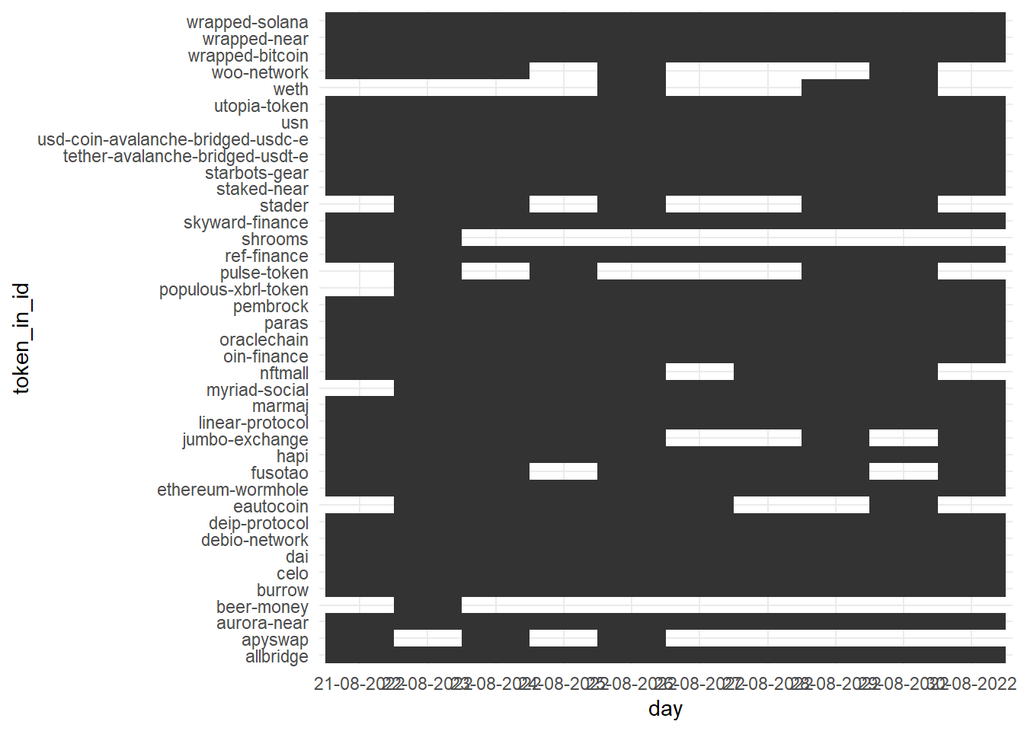

```r
library(ggplot2)
ggplot(data) +
 aes(x = day, y = token_in_id, group = day) +
 geom_tile(size = 1.2) +
 theme_minimal()
```